# BoredPanda Task1

Tomas Dzedulionis

2020

[figure not shown]

## Info

Report was created using R programming language. Everything is automated and updatable by one click. Code can be found in my [GitHub](https://github.com/tomasdzedulionis/BoredPanda).  
Hope you enjoy it!  
Tomas.

## Summary Tables

### All

This table demonstrates *TOTAL REVENUE BY ADVERTISER AND PLACEMENT*.

| Placement | Revenue |
| --- | --- |
| **Ad Exchange** |  |
| MM_BPCOM_HBS_Placement | €119036.06 |
| MM_BPES_HBS_Placement | €1651.92 |
| MM_DE_HBS_Placement | €2296.54 |
| **AdSense** |  |
| MM_BPCOM_HBS_Placement | €107.04 |
| MM_BPES_HBS_Placement | €1 |
| **Amazon** |  |
| MM_BPCOM_HBS_Placement | €20432.54 |
| **Infolinks Media** |  |
| MM_BPCOM_HBS_Placement | €918.52 |
| **Optima network** |  |
| MM_BPCOM_HBS_Placement | €1447.66 |
| **Optima network de** |  |
| MM_DE_HBS_Placement | €175.22 |
| **Optima network es** |  |
| MM_BPES_HBS_Placement | €28.4 |
| **Total** |  |
|  | €146094.9 |

This table demonstrates *TOTAL IMPRESSIONS BY ADVERTISER AND PLACEMENT*.

| Placement | Impressions |
| --- | --- |
| **Ad Exchange** |  |
| MM_BPCOM_HBS_Placement | 145758630.0 |
| MM_BPES_HBS_Placement | 5241322.5 |
| MM_DE_HBS_Placement | 4132093.5 |
| **AdSense** |  |
| MM_BPCOM_HBS_Placement | 8026726.5 |
| MM_BPES_HBS_Placement | 73980.0 |
| **Amazon** |  |
| MM_BPCOM_HBS_Placement | 9533179.5 |
| **Infolinks Media** |  |
| MM_BPCOM_HBS_Placement | 542592.0 |
| **Optima network** |  |
| MM_BPCOM_HBS_Placement | 6653548.5 |
| **Optima network de** |  |
| MM_DE_HBS_Placement | 219027.0 |
| **Optima network es** |  |
| MM_BPES_HBS_Placement | 106414.5 |
| **Total** |  |
| Total | 180287514.0 |

This table demonstrates *TOTAL REVENUES AND IMPRESSIONS OF THE PAST 7 DAYS*.

| Date | Revenue | Impressions |
| --- | --- | --- |
| 2020-11-16 | €5787.12 | 6913364 |
| 2020-11-17 | €5970.12 | 7194255 |
| 2020-11-18 | €7329.3 | 8266773 |
| 2020-11-19 | €10021.22 | 11497523 |
| 2020-11-20 | €8408 | 9039795 |
| 2020-11-21 | €11027.84 | 12133131 |
| 2020-11-22 | €7293.52 | 7899186 |
| **TOTAL** |  |  |
| Total | €55837.12 | 62944026 |

### MM_BPCOM_HBS

This table demonstrates *Total and last 7 days impressions and revenues of MM_BPCOM_HBS placement*

| Date | Revenue | Impressions |
| --- | --- | --- |
| **Month Total** |  |  |
|  | €38684.94 | 25726811 |
| **Last 7 days** |  |  |
| 2020-11-08 | €1991.14 | 1264232 |
| 2020-11-09 | €2074.54 | 1414787 |
| 2020-11-10 | €2305.58 | 1546205 |
| 2020-11-11 | €2606.66 | 1717499 |
| 2020-11-12 | €2719.06 | 1846313 |
| 2020-11-13 | €3235.6 | 2214009 |
| 2020-11-14 | €3054.5 | 2055912 |
| **Last 7 days total** |  |  |
|  | €17987.08 | 12058955 |

This table demonstrates *Total revenue and impressions by advertisers in the past month*

| Advertisers | Revenue | Impressions |
| --- | --- | --- |
| rubicon | €5514.76 | 3648759.0 |
| pubmatic | €4983.26 | 3375516.0 |
| ix | €4872.8 | 2433205.5 |
| onemobile | €4841.52 | 4910322.0 |
| aol | €4833.16 | 1797712.5 |
| appnexus | €2912.56 | 1987288.5 |
| conversant | €2291.28 | 1073781.0 |
| sovrn | €1923.5 | 1661742.0 |
| 33across | €1854.5 | 917748.0 |
| openx | €1642.52 | 1211011.5 |
| rhythmone | €1038.08 | 1288483.5 |
| emx_digital | €884.78 | 656434.5 |
| districtmdmx | €455.8 | 168708.0 |
| oftmedia | €400.38 | 469726.5 |
| districtm | €236.04 | 126366.0 |
| criteo | €0 | 6.0 |

### MM_BPES_HBS

This table demonstrates *Total and last 7 days impressions and revenues of MM_BPES_HBS placement*

| Date | Revenue | Impressions |
| --- | --- | --- |
| **Month Total** |  |  |
|  | €414.66 | 613435.5 |
| **Last 7 days** |  |  |
| 2020-11-11 | €42 | 53436.0 |
| 2020-11-12 | €36.32 | 45967.5 |
| 2020-11-13 | €29.48 | 39600.0 |
| 2020-11-14 | €26.56 | 35814.0 |
| 2020-11-15 | €32.32 | 47592.0 |
| 2020-11-16 | €27.64 | 41923.5 |
| 2020-11-17 | €29.66 | 45153.0 |
| **Last 7 days total** |  |  |
|  | €223.98 | 309486.0 |

This table demonstrates *Total revenue and impressions by advertisers in the past month*

Total revenue and impressions by advertisers in the past month

| Advertisers | Revenue | Impressions |
| --- | --- | --- |
| appnexus | €84 | 118312.5 |
| rubicon | €74 | 108934.5 |
| onemobile | €59.78 | 87019.5 |
| pubmatic | €44.14 | 68581.5 |
| ix | €43.5 | 67765.5 |
| rhythmone | €34.48 | 41451.0 |
| sovrn | €22.52 | 54688.5 |
| oftmedia | €22.44 | 34141.5 |
| aol | €15.52 | 3988.5 |
| emx_digital | €9.68 | 17658.0 |
| openx | €4.42 | 10783.5 |
| districtm | €0.12 | 72.0 |
| districtmdmx | €0.06 | 39.0 |

### MM_DE_HBS

This table demonstrates *Total and last 7 days impressions and revenues of MM_DE_HBS placement*

| Date | Revenue | Impressions |
| --- | --- | --- |
| **Month Total** |  |  |
|  | $247.2 | 202435.5 |
| **Last 7 days** |  |  |
| 2020-11-10 | $10.1 | 7869.0 |
| 2020-11-11 | $15.22 | 12280.5 |
| 2020-11-12 | $24.18 | 15844.5 |
| 2020-11-13 | $21.2 | 15432.0 |
| 2020-11-14 | $17.88 | 13923.0 |
| 2020-11-15 | $14.86 | 10573.5 |
| 2020-11-16 | $0.88 | 418.5 |
| **Last 7 days total** |  |  |
|  | $104.32 | 76341.0 |

This table demonstrates *Total revenue and impressions by advertisers in the past month*

Total revenue and impressions by advertisers in the past month

| Advertisers | Revenue | Impressions |
| --- | --- | --- |
| ix | €55.18 | 35691.0 |
| aol | €45.62 | 17872.5 |
| pubmatic | €39.16 | 35226.0 |
| rubicon | €20.26 | 21337.5 |
| appnexus | €20.02 | 22041.0 |
| rhythmone | €16.62 | 10416.0 |
| emx_digital | €10.52 | 17991.0 |
| openx | €10.28 | 13732.5 |
| sovrn | €9.74 | 11154.0 |
| 33across | €6.66 | 4669.5 |
| onemobile | €5.52 | 4377.0 |
| oftmedia | €3.1 | 5535.0 |
| districtmdmx | €2.92 | 1186.5 |
| districtm | €1.6 | 1206.0 |

## Plots

### Revenue

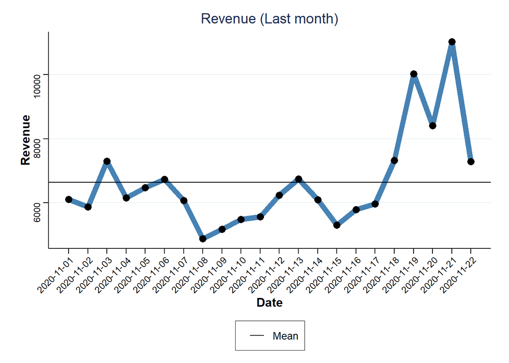

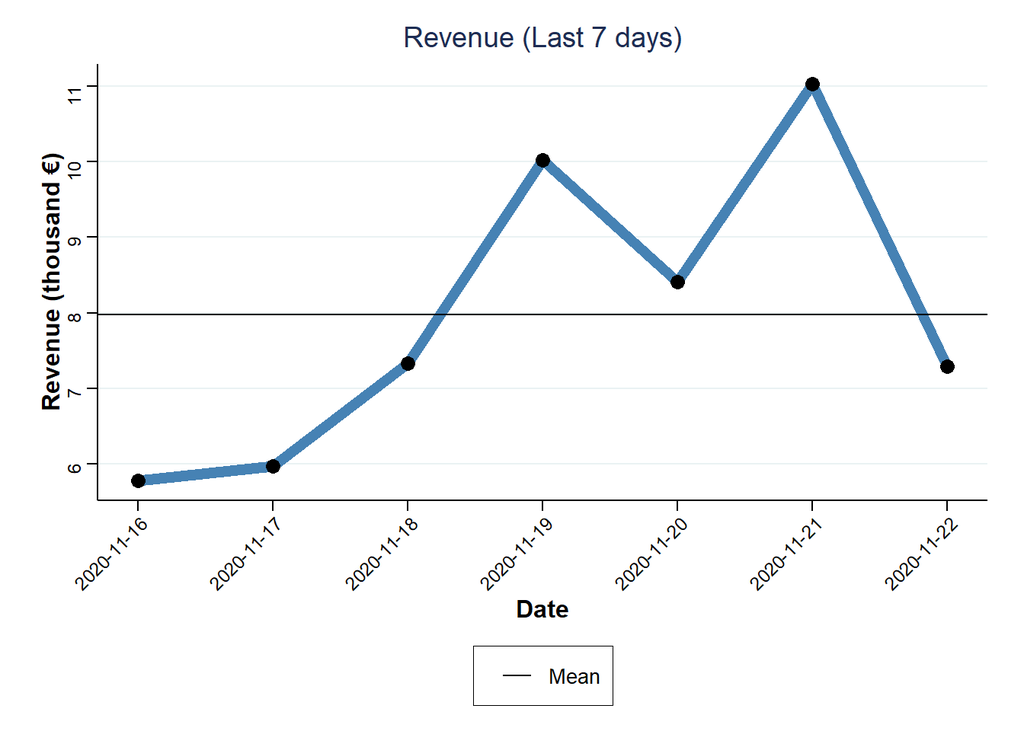

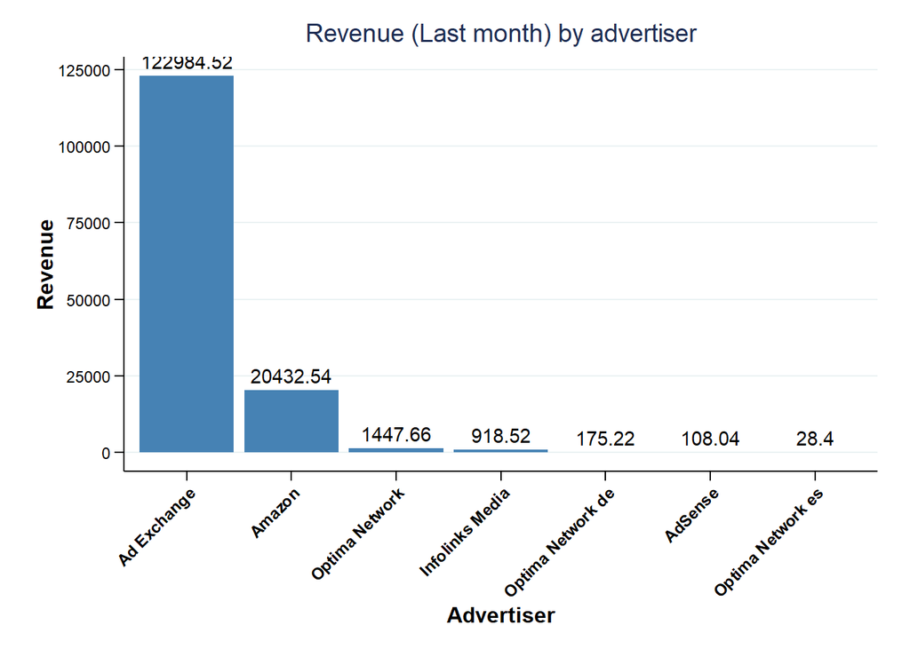

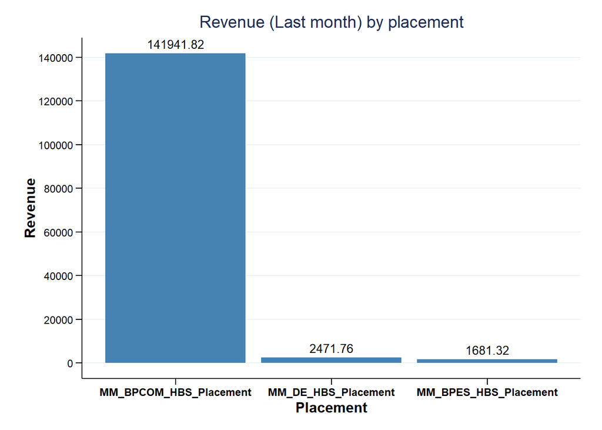

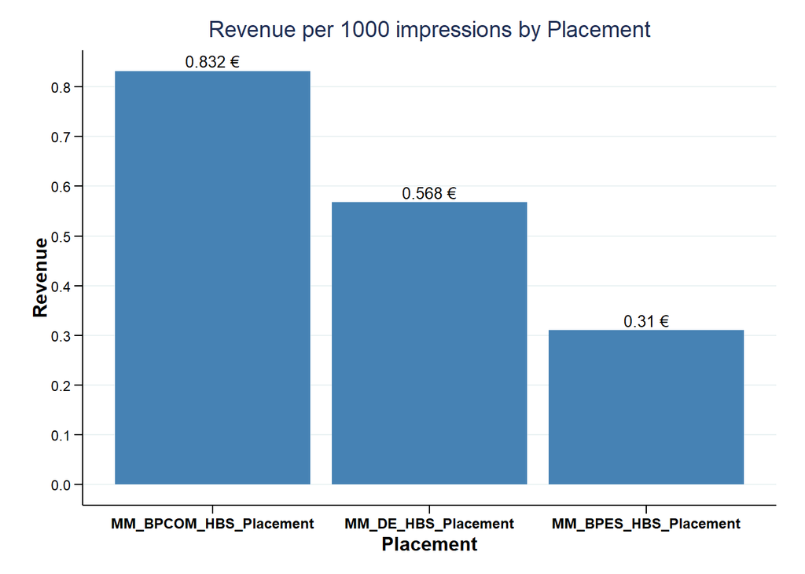

```
## [1] "C"
```

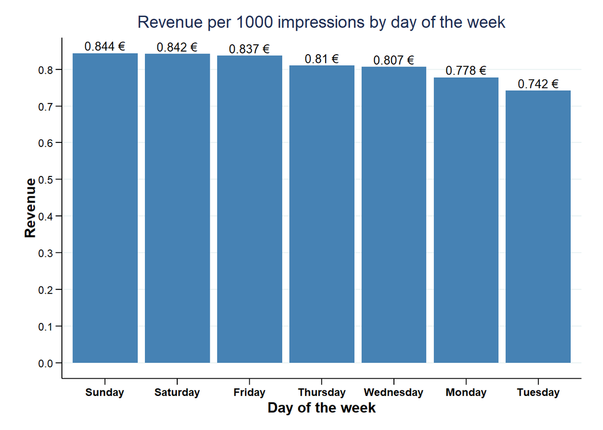

### Impressions

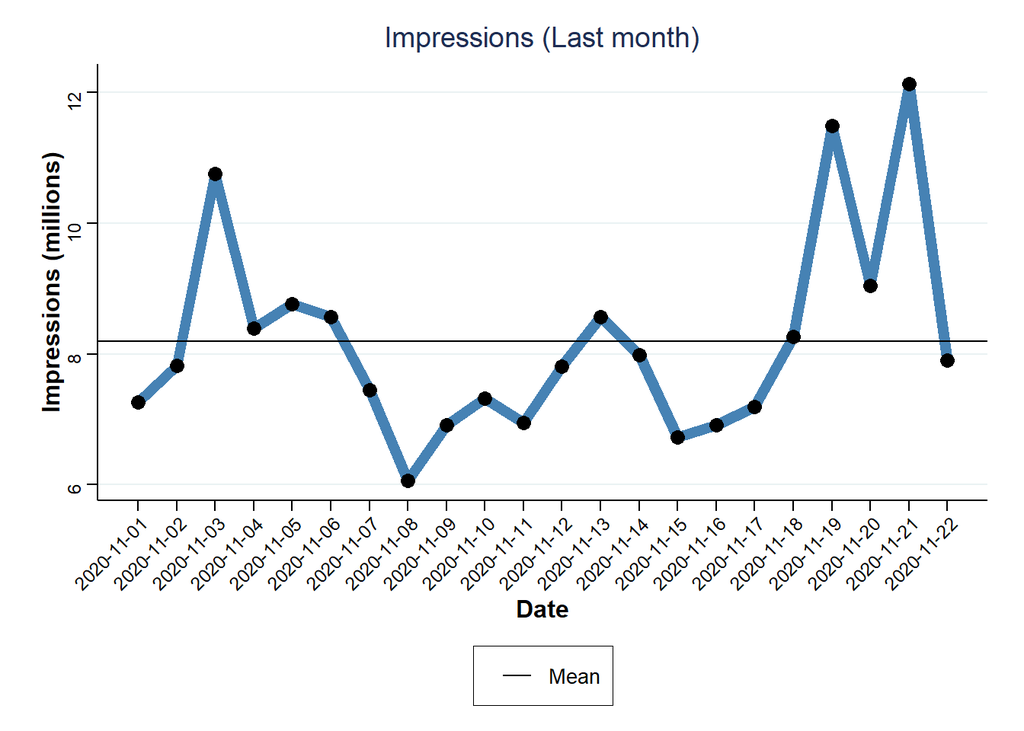

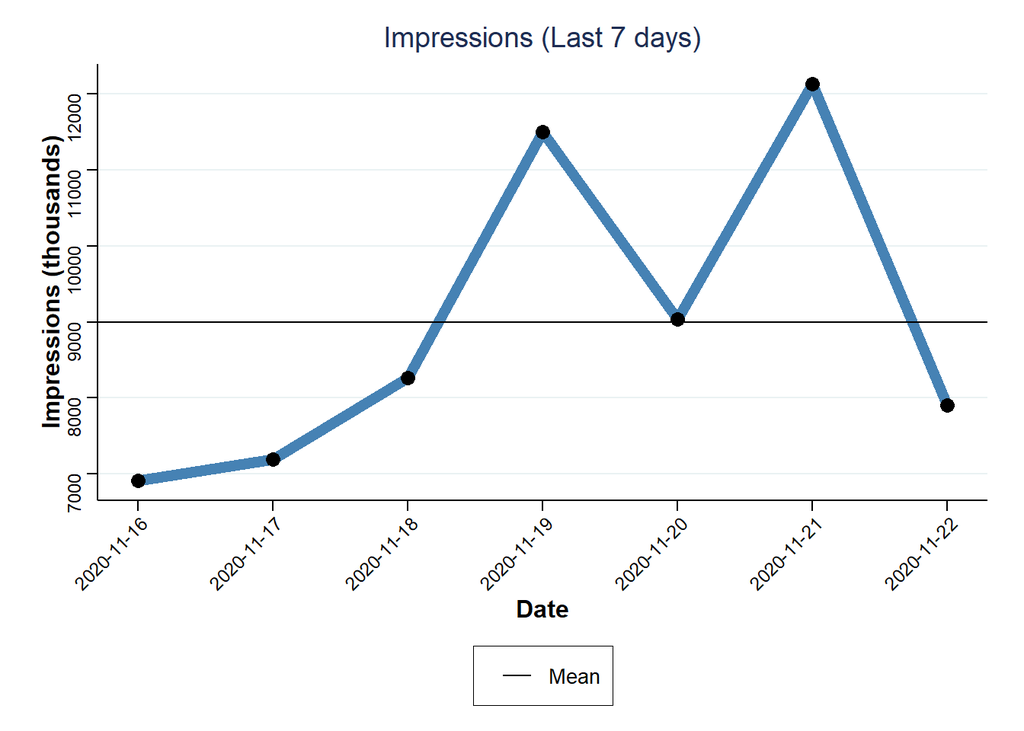

```
## [1] "C"
```

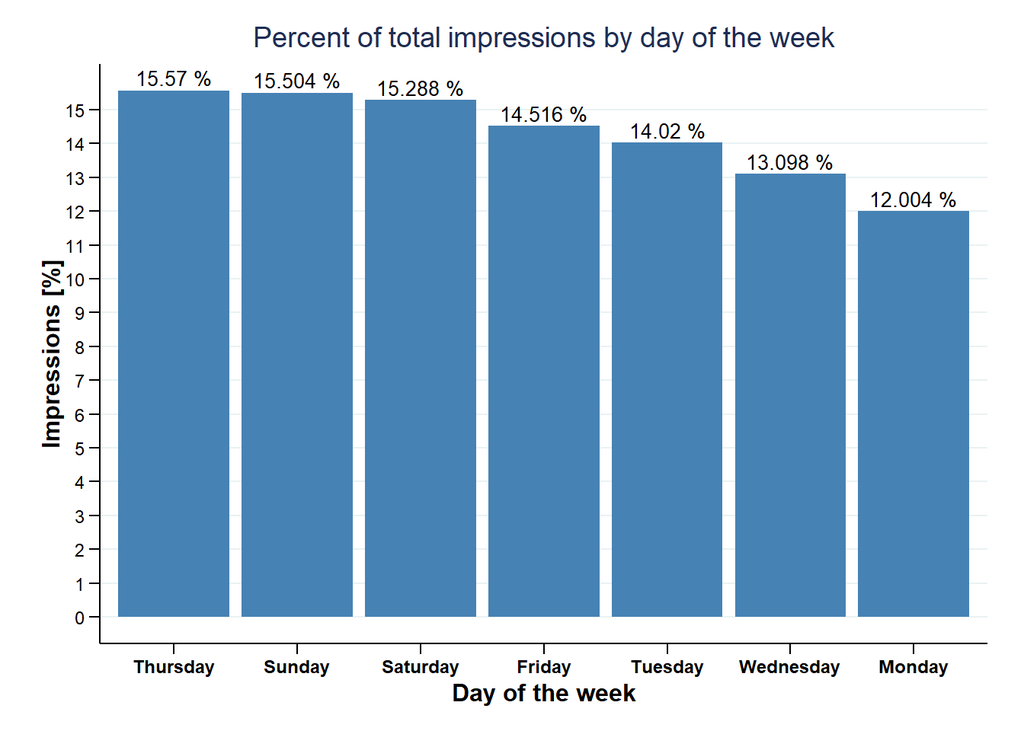

### MM_BPCOM_HBS

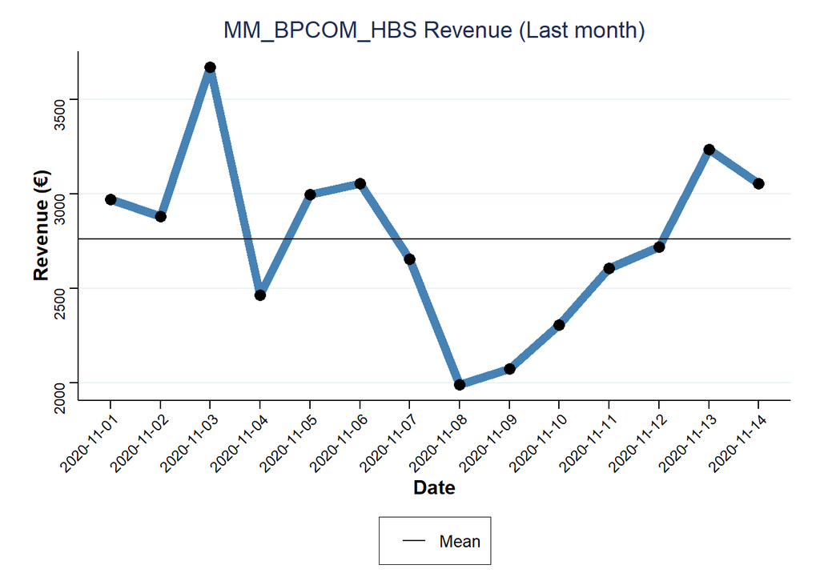

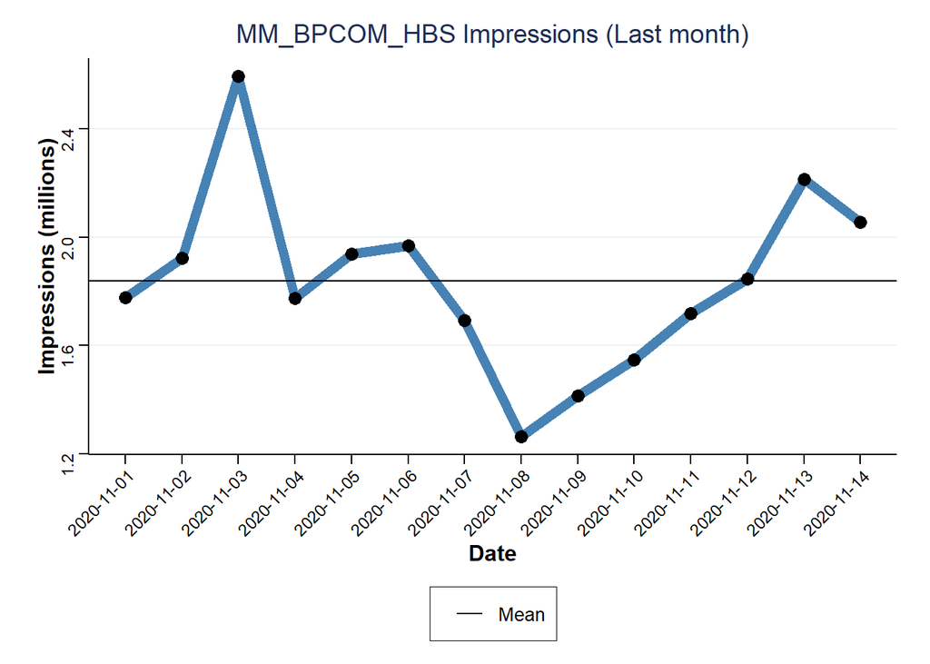

### MM_BPES_HBS

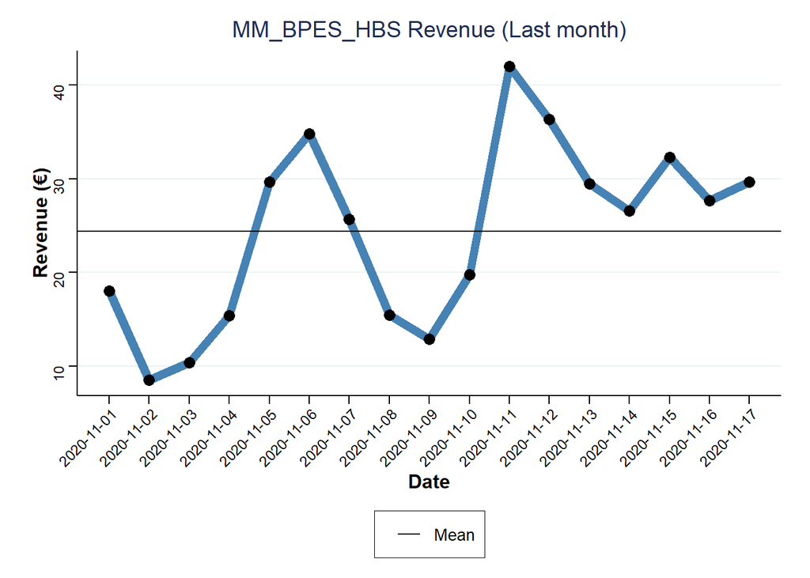

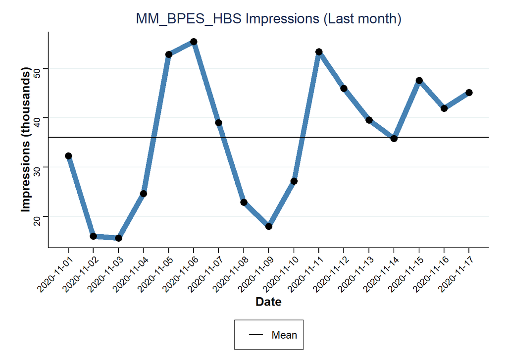

### MM_DE_HBS

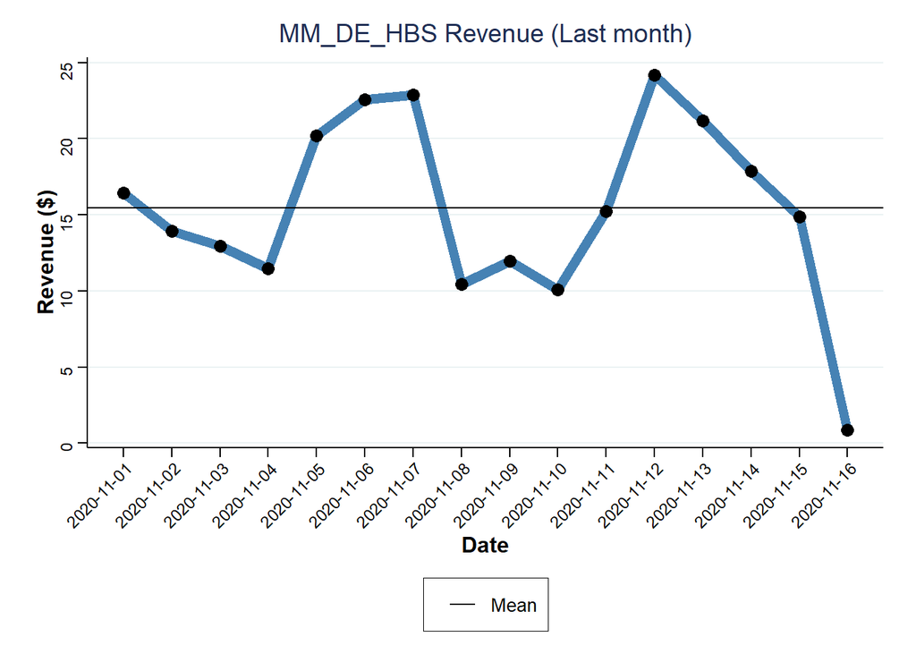

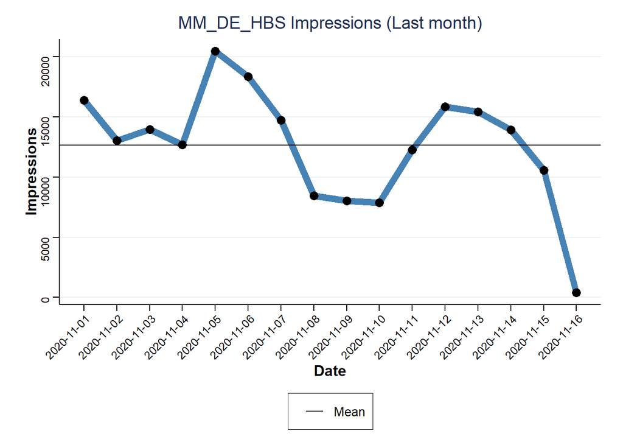